# Soil Effects on Presence/Absence Analysis

```r
data2009 <-read.csv("2009.Data.Entry.Copy.csv", header=TRUE, sep=",", stringsAsFactors = FALSE)
str(data2009)
```

```
'data.frame':   675 obs. of  9 variables:
 $ Year        : int  2009 2009 2009 2009 2009 2009 2009 2009 2009 2009 ...
 $ Month       : chr  "July" "July" "July" "July" ...
 $ Day         : logi  NA NA NA NA NA NA ...
 $ SiteName    : chr  "Grazing" "Grazing" "Grazing" "Grazing" ...
 $ SiteCode    : int  1 1 1 1 1 1 1 1 1 1 ...
 $ PlotNumber  : chr  "GT1Q1" "GT1Q1" "GT1Q1" "GT1Q1" ...
 $ Species_Code: chr  "ArH" "ArS" "ChAcc" "CS" ...
 $ Count       : int  1 16 57 4 8 4 15 1 12 3 ...
 $ Cover       : num  10 10 10 5 15 5 2 20 2 1 ...
```

```r
data2018 <-read.csv("2018.Data.Entry.Copy.csv", header = TRUE, sep = ",",stringsAsFactors = FALSE)
str(data2018)
```

```
'data.frame':   142 obs. of  9 variables:
 $ Year       : int  2018 2018 2018 2018 2018 2018 2018 2018 2018 2018 ...
 $ Month      : chr  "July" "July" "July" "July" ...
 $ Day        : int  16 16 16 16 16 16 16 16 16 16 ...
 $ SiteName   : chr  "Control" "Control" "Control" "Control" ...
 $ Transect   : int  1 1 1 1 1 1 2 2 2 2 ...
 $ PlotNumber : chr  "QCG1" "QCG1" "QCG1" "QCG1" ...
 $ SpeciesCode: chr  "LD" "conv" "CA" "CS" ...
 $ Cover      : num  60 5 5 25 20 NA 35 55 5 15 ...
 $ X          : logi  NA NA NA NA NA NA ...
```

pulled in both data sets of data from csv files

```r
d18<-data2018$SiteName[data2018$SiteName=="Naimen"]<-"Naiman"
```

```r
d09<-dplyr::rename(data2009,Transect = SiteCode)
```

renamed sitecode to transect in 2009 data to match 2018 and created a new dataframe with manipulated

```r
##install.packages("reshape2")
library(reshape)
d09pc <- cast(d09,SiteName + PlotNumber ~ Species_Code, value='Cover', FUN=mean)
```

installed reshape package and casted data by species type and site code. Used cover as value to track basic presence/absence for 2009 data

```r
d18<-dplyr::rename(data2018,Species_Code = SpeciesCode)
```

reloaded dplyr pakage, and renamed SpeciesCode to match d09

```r
d18pc <- cast(d18,SiteName + PlotNumber ~ Species_Code, value='Cover', FUN=mean)
```

performed same cast function for d18 to obtain presence absence

```r
library(dplyr)
library(reshape)
d18<-dplyr::rename(data2018,Species_Code = SpeciesCode)
d18pc <- cast(d18,SiteName + PlotNumber ~ Species_Code, value='Cover', FUN=mean)
```

load dplyr package, created new data frame for manipulation of data called d18. Casted d18 into d18pc for presence/absence.

```r
statsd09 <- d09 %>% group_by(SiteName) %>% group_by(Species_Code) %>% summarize(avg = mean(Cover))
statsd18 <- d18 %>% group_by(SiteName) %>% group_by(Species_Code) %>% summarize(avg = mean(Cover))
View(statsd09)
View(statsd18)
```

Created new data frame that contains the summary cover statistics of mean cover for each species within 2009 data repeated the same steps for 2018 data. Used View function to confirm data has been subsetted in the way that I wanted ##summd09pa<- dcast(statsd09,~Species_Code, value.var =‘avg’, FUN=mean) summd18pa<- dcast(statsd09,~Species_Code, value.var =‘avg’, FUN=mean) cast summary data to view the species cover by average

```r
d09pc <- as.data.frame(d09pc)
d18pc <- as.data.frame(d18pc)
```

changing both casts from 2009 and 2018 to data frames so that NA values can be converted into 0

```r
d09pc[is.na(d09pc)] <- 0
d18pc[is.na(d18pc)] <- 0
```

changed NA to 0

```r
library(reshape)
d09pc.matrix <- as.matrix.cast_df(d09pc)
d18pc.matrix <- as.matrix.cast_df(d18pc)
```

casted to a matrix

```r
naiman09.avg <- d09 %>% filter(SiteName == "Naiman") %>% group_by(Species_Code) %>% summarise(avg = mean(Cover))
grazing09.avg <- d09 %>% filter(SiteName == "Grazing") %>% group_by(Species_Code) %>% summarise(avg = mean(Cover))
```

calculated mean cover by site, grouped by species for 2009 data.

```r
naiman18.avg <- d18 %>% filter(SiteName == "Naiman") %>% group_by(Species_Code) %>% summarise(avg = mean(Cover))
control18.avg <- d18 %>% filter(SiteName == "Control") %>% group_by(Species_Code) %>% summarise(avg = mean(Cover))
grazing18.avg <- d18 %>% filter(SiteName == "Grazing") %>% group_by(Species_Code) %>% summarise(avg = mean(Cover))
heavy18.avg <- d18 %>% filter(SiteName == "Heavy") %>% group_by(Species_Code) %>% summarise(avg = mean(Cover))
light18.avg <- d18 %>% filter(SiteName == "Light") %>% group_by(Species_Code) %>% summarise(avg = mean(Cover))
```

ran the same function for 2018 data to calculate mean

```r
naiman09.med <- d09 %>% filter(SiteName == "Naiman") %>% group_by(Species_Code) %>% summarise(med = median(Cover))
grazing09.med <- d09 %>% filter(SiteName == "Grazing") %>% group_by(Species_Code) %>% summarise(med = median(Cover))
naiman09.sd <- d09 %>% filter(SiteName == "Naiman") %>% group_by(Species_Code) %>% summarise(std = sd(Cover))
grazing09.sd <- d09 %>% filter(SiteName == "Grazing") %>% group_by(Species_Code) %>% summarise(std = sd(Cover))
naiman18.med <-d18 %>% filter(SiteName == "Naiman") %>% group_by(Species_Code) %>% summarise(med = median(Cover))
control18.med <- d18 %>% filter(SiteName == "Control") %>% group_by(Species_Code) %>% summarise(med = median(Cover))
grazing18.med <-d18 %>% filter(SiteName == "Grazing") %>% group_by(Species_Code) %>% summarise(med = median(Cover))
heavy18.med <-d18 %>% filter(SiteName == "Heavy") %>% group_by(Species_Code) %>% summarise(med = median(Cover))
light18.med <-d18 %>% filter(SiteName == "Light") %>% group_by(Species_Code) %>% summarise(med = median(Cover))
naiman18.sd <-d18 %>% filter(SiteName == "Naiman") %>% group_by(Species_Code) %>% summarise(std = sd(Cover))
control18.sd <-d18 %>% filter(SiteName == "Control") %>% group_by(Species_Code) %>% summarise(std = sd(Cover))
grazing18.sd <-d18 %>% filter(SiteName == "Grazing") %>% group_by(Species_Code) %>% summarise(std = sd(Cover))
heavy18.sd <-d18 %>% filter(SiteName == "Heavy") %>% group_by(Species_Code) %>% summarise(std = sd(Cover))
light18.sd <-d18 %>% filter(SiteName == "Light") %>% group_by(Species_Code) %>% summarise(std = sd(Cover))
```

Found median cover and std for species by sites for 2009 and 2018 data and assigned to their own data frame Attempted a table join of Naiman 2009 summary statistics.

```r
naiman09.allstats <- left_join(naiman09.avg,naiman09.med, by = "Species_Code")
View(naiman09.allstats)
naiman09.summ.stat <- left_join(naiman09.allstats,naiman09.sd, by = "Species_Code")
```

Attempted a table join of Naiman 2009 summary statistics.

```r
naiman18.summ.stats <- left_join(naiman18.avg,naiman18.med, by='Species_Code') %>% left_join(.,naiman18.sd, by='Species_Code')
grazing18.summ.stats <- left_join(grazing18.avg,grazing18.med, by='Species_Code') %>% left_join(.,grazing18.sd, by='Species_Code')
control18.summ.stats <- left_join(control18.avg,control18.med, by='Species_Code') %>% left_join(.,control18.sd, by='Species_Code')
heavy18.summ.stats <- left_join(heavy18.avg,heavy18.med, by='Species_Code') %>% left_join(.,heavy18.sd, by='Species_Code')
light18.summ.stats <- left_join(light18.avg,light18.med, by='Species_Code') %>% left_join(.,light18.sd, by='Species_Code')
grazing09.summ.stats <- left_join(grazing09.avg,grazing09.med, by='Species_Code') %>% left_join(.,grazing09.sd, by='Species_Code')
```

Realized, I could not join more than 2 tables at atime, so I ran separate joins for STD, however found that by piping I could complete the process faster, with less code. So I completed the join of the data tables of summary statistics for remaining sites in both years 2009 and 2018 data as grouped species

```r
naiman09.summ.stats <- left_join(naiman09.avg,naiman09.med, by='Species_Code') %>% left_join(.,naiman09.sd, by='Species_Code')
```

re-did table join for Naiman 2009 so that naming convention and process matched the rest of the data

```r
med.site.d18 <- d18 %>% group_by(SiteName) %>% summarize(median.of.all.sites = median(Cover))
med.site.d09 <- d09 %>% group_by(SiteName) %>% summarize(median.of.all.sites = median(Cover))
avg.d18 <- d18 %>% group_by(SiteName) %>% summarize(avg = mean(Cover))
avg.d09 <- d09 %>% group_by(SiteName) %>% summarize(avg = mean(Cover))
std.d09 <- d09 %>% group_by(SiteName) %>% summarize(std = sd(Cover))
std.d18 <- d18 %>% group_by(SiteName) %>% summarize(std = sd(Cover))
allsites09.summ.stats <- left_join(avg.d09,med.site.d09, by='SiteName') %>% left_join(.,std.d09, by='SiteName')
allsites18.summ.stats <- left_join(avg.d18,med.site.d18, by='SiteName') %>% left_join(.,std.d18, by='SiteName')
```

calculated remaining summary statistics across all sites and placed them into a table together

```r
library(knitr)
kable(naiman09.summ.stats, caption = "Naiman 2009 Summary Statistics")
```

```
|Species_Code |        avg|   med|       std|
|:------------|----------:|-----:|---------:|
|AH           |  31.333333|  20.0| 32.072834|
|Arisads      |  11.250000|  12.5|  6.713526|
|Bassia       |  10.611111|   5.0| 12.297861|
|ChAcc        |  14.900000|  10.0| 15.443956|
|CHAcc        |   9.333333|  10.0|  1.154700|
|ChenAC       |   1.000000|   1.0|        NA|
|CM           |  28.333333|  25.0|  7.527726|
|Cormac       |   9.000000|  10.0|  3.605551|
|CorMac       |   6.064516|   4.0|  5.415629|
|Cyncthes     |   6.550000|   5.0|  5.762629|
|Dodder       |   6.250000|   2.0|  9.215024|
|EP           |   1.000000|   1.0|  0.000000|
|Equis        |  14.000000|  14.0|  8.485281|
|Erogpoa      |  20.000000|  20.0|        NA|
|Euph.A       |  11.080000|  10.0|  8.286133|
|Euphhed      |  23.333333|  25.0|  7.637626|
|LD           |  25.500000|  15.0| 24.468976|
|MR           |  37.166667|  35.0| 35.824107|
|POAQ         |   2.000000|   2.0|        NA|
|Portulaca    |  10.000000|  10.0|        NA|
|Qforb1       |  15.000000|  15.0|        NA|
|Qforb2       |  14.500000|  14.5| 14.849242|
|QG1          |  15.000000|  15.0|        NA|
|QG2          |   1.000000|   1.0|        NA|
|QL3          | 100.000000| 100.0|        NA|
|Salsola      |  20.383333|  15.0| 16.727215|
|setaria      |  13.022727|  10.0| 15.108120|
|Setaria      |  15.000000|  15.0|        NA|
|TT           |   2.000000|   2.0|  0.000000|
```

```r
kable(naiman18.summ.stats, caption = "Naiman 2018 Summary Statistics")
```

```
|Species_Code |       avg|  med|       std|
|:------------|---------:|----:|---------:|
|AA           | 10.000000| 10.0|  0.000000|
|bare         | 12.250000| 12.5| 10.210289|
|BD           | 10.000000| 10.0|        NA|
|CA           | 35.000000| 35.0|        NA|
|CM           |  2.666667|  2.0|  2.081666|
|CS           |  5.333333|  5.0|  2.516611|
|CT           | 17.500000| 17.5| 17.677670|
|EP           |  7.500000|  7.5|  3.535534|
|Eph          | 21.666667| 15.0| 11.547005|
|EuphA        | 17.500000| 17.5|  3.535534|
|L            | 15.000000| 12.5| 10.801234|
|LD           | 11.666667| 10.0|  7.637626|
|SV           | 17.500000| 17.5|  8.660254|
|TT           | 25.000000| 15.0| 21.794495|
```

```r
kable(grazing09.summ.stats, caption = "Grazing 2009 Summary Statistics")
```

```
|Species_Code |       avg|  med|        std|
|:------------|---------:|----:|----------:|
|Alsen        | 10.062500| 10.0|  8.0619993|
|ArH          | 10.000000| 10.0|         NA|
|ArS          | 10.000000| 10.0|         NA|
|ArSc         | 11.615385|  6.5| 11.3563266|
|Bassia       |  6.064516|  5.0|  4.8209616|
|ChAcc        |  8.516129|  6.0|  5.3781717|
|CHAcc        |  7.157895|  8.0|  6.3706197|
|ChenQ        |  9.714286|  8.0|  7.8679579|
|ChQ          | 11.250000| 13.5|  7.0051002|
|CM           | 13.333333| 10.0| 10.4083300|
|Cormac       |  1.000000|  1.0|         NA|
|CorMac       |  5.142857|  5.0|  3.6253079|
|CS           |  6.857143|  5.0|  4.9067968|
|Cyncthes     |  6.000000|  6.0|  5.6568542|
|Equisetum    | 17.500000| 17.5|  3.5355339|
|Erod         |  6.500000|  6.5|  7.7781746|
|LD           | 22.166667| 15.0| 18.1153710|
|LS           | 10.400000|  6.0|  9.6332757|
|PD           |  5.000000|  5.0|         NA|
|PQ           | 15.083333| 15.0|  7.8097647|
|QG1          |  5.000000|  5.0|         NA|
|QG2          |  2.000000|  2.0|         NA|
|QG3          |  9.500000|  9.5| 12.0208153|
|QP           | 10.000000| 10.0|         NA|
|Qsubsh       | 40.000000| 40.0|         NA|
|SalixQ       | 85.000000| 85.0|         NA|
|Salsola      | 11.717742|  8.0| 13.3756020|
|setaria      |  4.437500|  3.0|  3.7765725|
|Thistle      |  4.666667|  4.5|  3.0110906|
|TT           |  1.500000|  1.0|  0.7071068|
|UNK          |  1.500000|  1.5|  0.7071068|
|UNK Shrub    | 70.000000| 70.0|         NA|
|UnkGS        |  1.000000|  1.0|         NA|
|UnkPer       | 20.000000| 20.0|         NA|
```

```r
kable(grazing18.summ.stats, caption = "Grazing 2018 Summary Statistics")
```

```
|Species_Code |       avg|  med|        std|
|:------------|---------:|----:|----------:|
|AA           |  2.500000|  2.5|  0.7071068|
|AF           | 15.000000| 15.0|         NA|
|All          |  3.875000|  3.5|  3.3260337|
|Aponyc       | 10.000000| 10.0|         NA|
|AS           | 12.500000| 12.5|  3.5355339|
|bare         | 30.000000| 30.0|  7.0710678|
|CA           |  4.000000|  4.0|  1.4142136|
|CM           | 11.250000|  8.5|  9.9456858|
|CS           | 20.000000| 25.0|  8.6602540|
|EL           |  5.000000|  5.0|         NA|
|EP           |  4.666667|  3.0|  4.7258156|
|EuphA        |  1.000000|  1.0|         NA|
|L            |  8.000000|  5.0|  8.1240384|
|LD           | 15.000000| 10.0|  8.6602540|
|PO           |  1.000000|  1.0|         NA|
|SV           | 11.600000| 10.0|  5.9413803|
|TT           | 14.333333|  2.0| 22.2336082|
```

```r
kable(light18.summ.stats, caption = "Light 2018 Summary Statistics")
```

```
|Species_Code |       avg|  med|       std|
|:------------|---------:|----:|---------:|
|AS           | 17.666667|  5.0| 23.692474|
|Bare         | 10.000000| 10.0|        NA|
|CS           | 35.000000| 20.0| 35.000000|
|EL           |  5.000000|  5.0|        NA|
|Euph2        | 20.000000| 20.0|        NA|
|EuphA        |  8.000000|  8.0|        NA|
|L            |  8.000000|  8.0|        NA|
|LD           | 45.000000| 45.0|        NA|
|PB           | 26.500000| 26.5| 26.162951|
|PC           |  9.333333|  8.0|  5.131601|
|Phrag        |  5.000000|  5.0|        NA|
|QG3          |  7.000000|  7.0|  4.242641|
|SV           | 40.000000| 40.0|        NA|
```

```r
kable(heavy18.summ.stats, caption = "Heavy 2018 Summary Statistics")
```

```
|Species_Code |      avg|  med|       std|
|:------------|--------:|----:|---------:|
|AH           | 23.33333| 20.0| 15.275252|
|conv         |  5.00000|  5.0|        NA|
|CS           | 27.50000| 27.5| 17.677670|
|LD           | 21.00000| 21.0| 12.727922|
|M            | 20.00000| 20.0|        NA|
|PC           | 40.00000| 40.0|        NA|
|SV           | 13.50000| 13.5|  4.949747|
```

```r
kable(control18.summ.stats, caption = "Control 2018 Summary Statistics")
```

```
|Species_Code |      avg|  med|       std|
|:------------|--------:|----:|---------:|
|AG           |  1.00000|  1.0|        NA|
|ArtH         | 65.00000| 65.0|        NA|
|bare         |       NA|   NA|        NA|
|CA           |  5.00000|  5.0|        NA|
|conv         |  5.00000|  5.0|        NA|
|CS           | 35.00000| 32.5| 15.811388|
|EuphA        | 15.00000| 15.0|        NA|
|L            | 31.66667| 20.0| 24.664414|
|LD           | 60.00000| 60.0|        NA|
|M            | 45.00000| 45.0|        NA|
|PB           | 30.00000| 30.0|        NA|
|Phrag        | 15.00000| 15.0|        NA|
|QF3          |  0.50000|  0.5|        NA|
|QForb3       |  1.00000|  1.0|        NA|
|QG1          | 17.50000| 17.5| 10.606602|
|SV           | 23.33333| 30.0| 16.072751|
|TT           | 10.00000| 10.0|  7.071068|
```

```r
kable(allsites09.summ.stats, caption = "All Sites 2009 Summary Statistics")
```

```
|SiteName |       avg| median.of.all.sites|      std|
|:--------|---------:|-------------------:|--------:|
|Grazing  |  9.190278|                   5| 10.36227|
|Naiman   | 14.563492|                  10| 16.44013|
```

```r
kable(allsites18.summ.stats, caption = "All Sites 2018 Summary Statistics")
```

```
|SiteName |      avg| median.of.all.sites|      std|
|:--------|--------:|-------------------:|--------:|
|Control  |       NA|                  NA|       NA|
|Grazing  | 11.83333|                10.0| 10.84708|
|Heavy    | 21.58333|                18.5| 12.76685|
|Light    | 18.76190|                10.0| 19.51129|
|Naiman   | 14.27027|                10.0| 11.09467|
```

knitted tables that were calculated for summary statistics into the markdown document

```r
library(dplyr)
library(vegan)
library(MASS)
library(tidyr)
library(MASS)
library(reshape2)
library(stringr)
```

loaded libraries to perform ordinations Calculate distance matrix below

```r
dis09.bray <- vegdist(d09pc.matrix, method = "bray")
dis18.bray <- vegdist(d18pc.matrix, method = "bray")
```

need to add in id for treatments and extract plot replicates, and site ids. NMDS calculated below.

```r
dis09.mds <- metaMDS(dis09.bray, trace = FALSE, autotransform = FALSE, shrink = FALSE)
dis18.mds <- metaMDS(dis18.bray, trace = FALSE, autotransform = FALSE, shrink = FALSE)
```

data for 2009

```r
treat = c(rep("Grazing",65), rep("Naiman",60))
sites <- d09pc[1:125,1]##use d09pc not matrix, extract site IDs
plots <- d09pc[1:125,2]
```

making a data frame by pulling out scores for each sites in 2009

```r
scores <- data.frame(scores(dis09.mds,display="sites"))
```

bind scores

```r
scores2 <- cbind(sites,scores)
```

plots 2009 data and drew a polygon around the spread

```r
plot(dis09.mds,type= "t")
```

```
species scores not available
```

```r
ordihull(dis09.mds,groups=treat,draw = "polygon", col ="grey90", label=T)
```

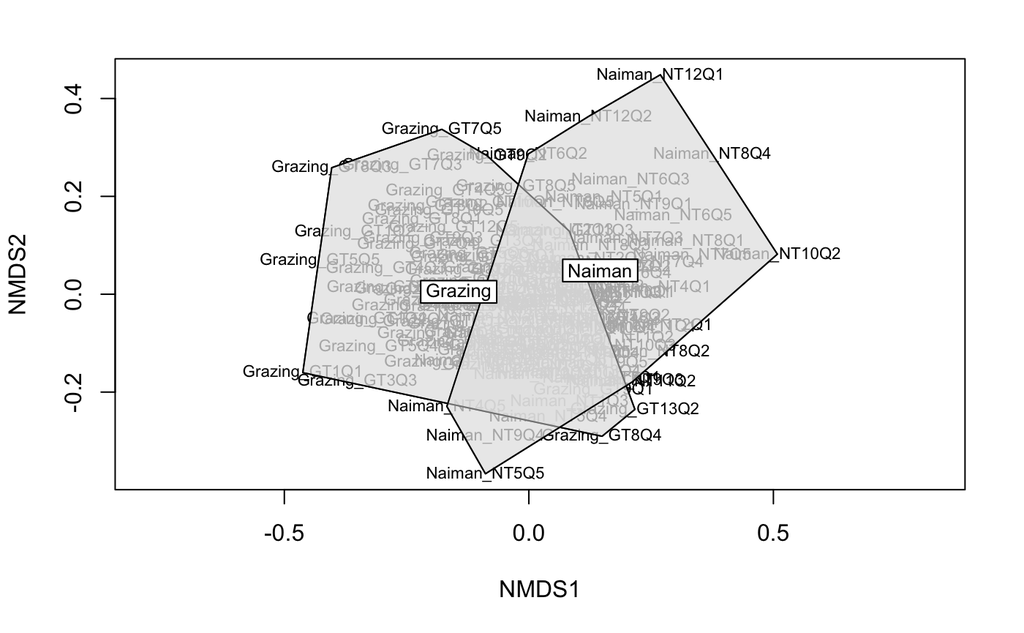

```r
ordihull(dis09.mds,groups=sites,draw = "polygon", col ="grey90", label=T)
```

```r
treat = c(rep("Control",5), rep("Grazing",5),rep("Heavy",4), rep("Light", 5), rep("Naiman",5) )
sites <- d18pc[1:24,1]##use d09pc not matrix, extract site IDs
plots <- d18pc[1:24,2]
scores <- data.frame(scores(dis18.mds,display="sites"))
scores2 <- cbind(sites,scores)
plot(dis18.mds,type= "t")
```

```
species scores not available
```

```r
##species scores not available
ordihull(dis18.mds,groups=treat,draw = "polygon", col ="grey90", label=T)
```

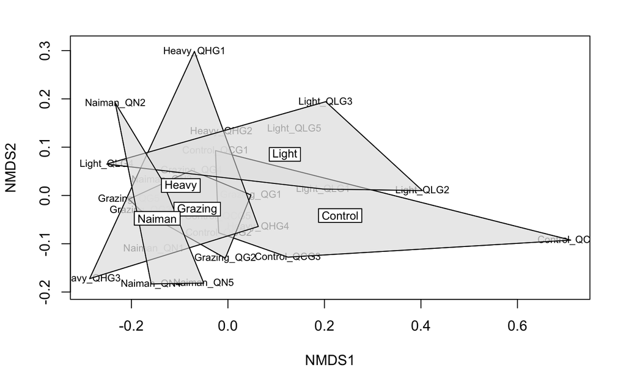

```r
ordihull(dis18.mds,groups=sites,draw = "polygon", col ="grey90", label=T)
```

```r
soils09 <- read.csv("Naiman_soils_copy.csv", header = TRUE, sep = ",", stringsAsFactors = FALSE)
str(soils09)
```

```
'data.frame':   40 obs. of  4 variables:
 $ Trt: chr  "Grazing" "Grazing" "Grazing" "Grazing" ...
 $ Rep: int  1 2 3 4 5 6 7 8 9 10 ...
 $ TN : num  0.39 0.33 0.231 0.39 0.55 0.33 0.32 0.23 0.4 0.29 ...
 $ TOC: num  7.11 6.1 3.4 6.02 10.39 ...
```

loaded 2009 soil data into the project as soils09